# 2023 AI Pacific Cod Forecasting

Maia S Kapur

2023-11-17

The basic models used herein are as follows. I also describe what was indicated in the *original* forecast file included with each model, which was passed to the scenario-building routine and presented to the GPT.

| Model | Description | Reference Points | Forecast Pars |
| --- | --- | --- | --- |
| 23.0a | Time blocks on K in 2003 and 2017 | Biology and selectivity averaged throughout time period for ref-point calculation. | Selectivity averaged from 2000-2019. |
| 23.0b | As 23.0a, with time blocks on fishery selex in 2002, 2012, 2016, and 2019. | as above | as above |
| 23.0c - Base Model | Time block on K in 2003, time block on M in 2015 | as above | as above |

Here’s what the *original* projection trajectories looked like (i.e., Scenario 1):

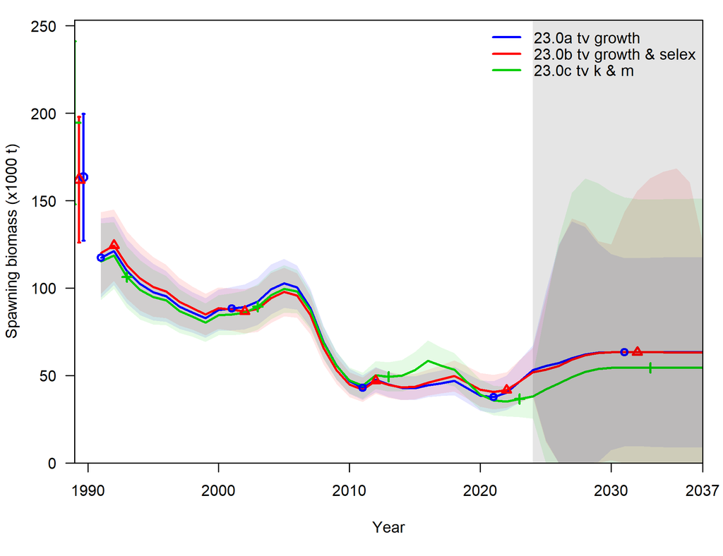

Figure 1. SSB Trajectories of models with original forecast file.

# Updating the SS Forecast file

The original approach averaged quantities (demographic and selectivity) across many blocks, and also had some inconsistency between the year ranges used for reference points and forecasted parameters.

*Averaging* across time blocks is unnecessary in certain cases (i.e. model 23.0a does not have time-varying selectivity, so no averaging is needed) and inappropriate in others (forecasts should represent what we reasonably expect to happen in the future, which is probably most similar to the present [versus an average of the past]). This is an issue for all models (since they all have time-varying quantities) but moreso for 23.0c since $M$ varies so greatly across time blocks, discussed below.

Specifying *different* time periods for the reference points and forecasted values produces confusion when comparing trajectories with targets. This is an issue for M23.0b, since the selectivity is averaged across all years for the reference points and only from 2000-2019 for forecasting. (This means that the target $F$ is calculated on a different selectivity than the population experiences during the forecast period).

For these reasons, my proposal is to instead use the terminal value for all quantities.

In the forecast file itself, this is represented as follows: `#_Bmark_years`

`0 0 0 0 0 0 0 0 0 0`

`#_Fcast_years:`

`0 0 0 0 -999 0`

Do note that *for this model*, only the first four values in “Bmark_years” and first two values of “Fcast_years” are used, because this model does not have multiple fishing fleets (thus no `relF`, no movement (thus no `recr_dist` nor `recruits` arguments), and no stock-recruit relationship.

## Impacts on Projections (Scenario 1)

The base model 23.0c has a high terminal value of $M$:

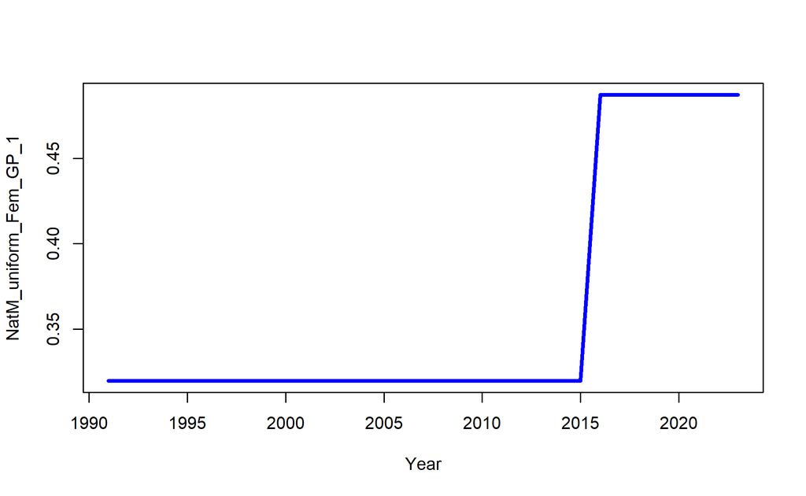

Figure 2. Time-varying natural mortailty in M23.0c.

The plot below shows the impact (on SSB) of changing the forecast file to only consider the terminal year for demography and selectivity when calculating reference points and parameterizing forecasts.

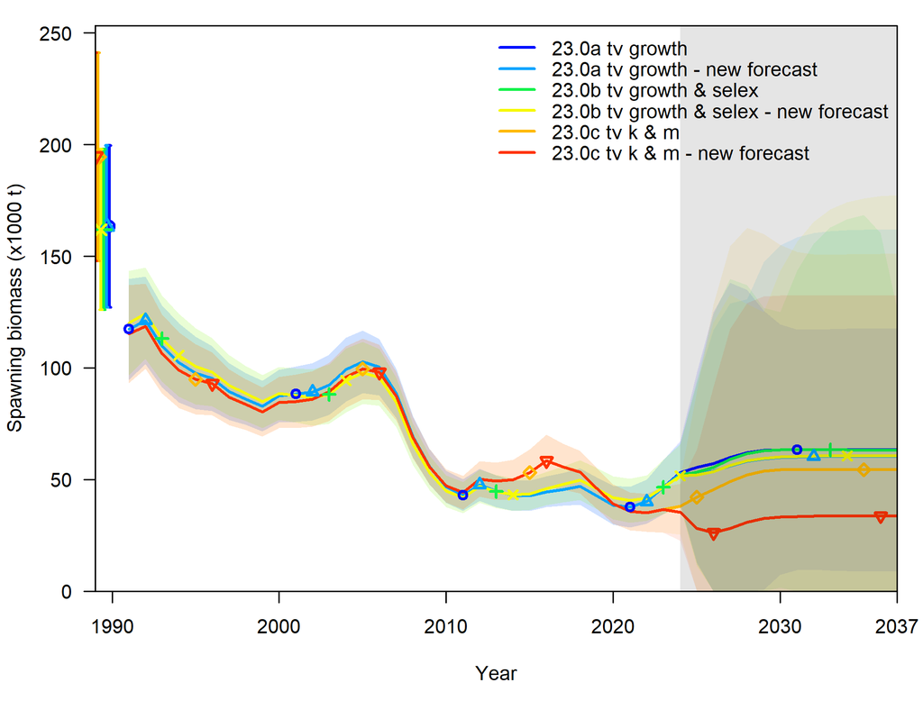

Figure 3. Comparison ofspawning biomass trajectories using original forecasting method, and forecasting method that only considers the terminal year for reference points and parameter values.

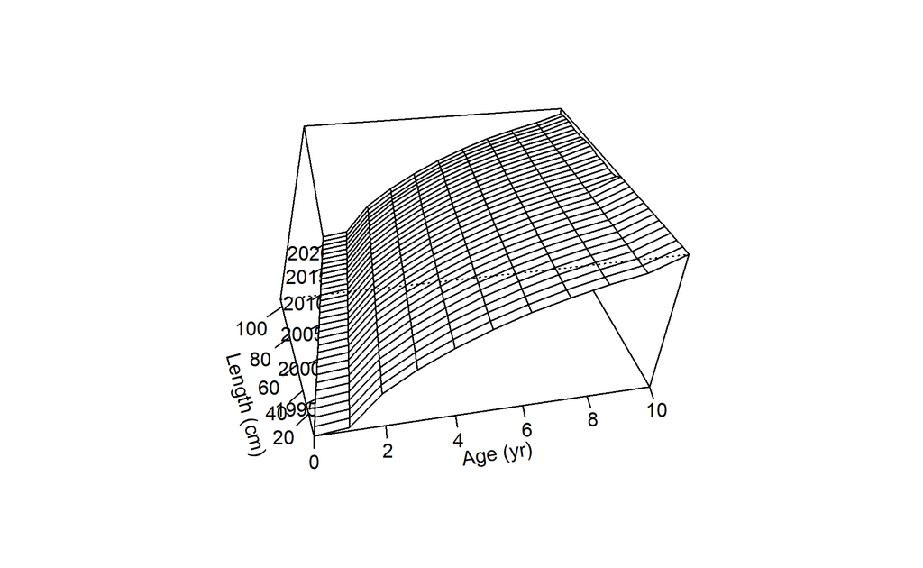

Figure 4. Time-varying Growth in M23.0a.

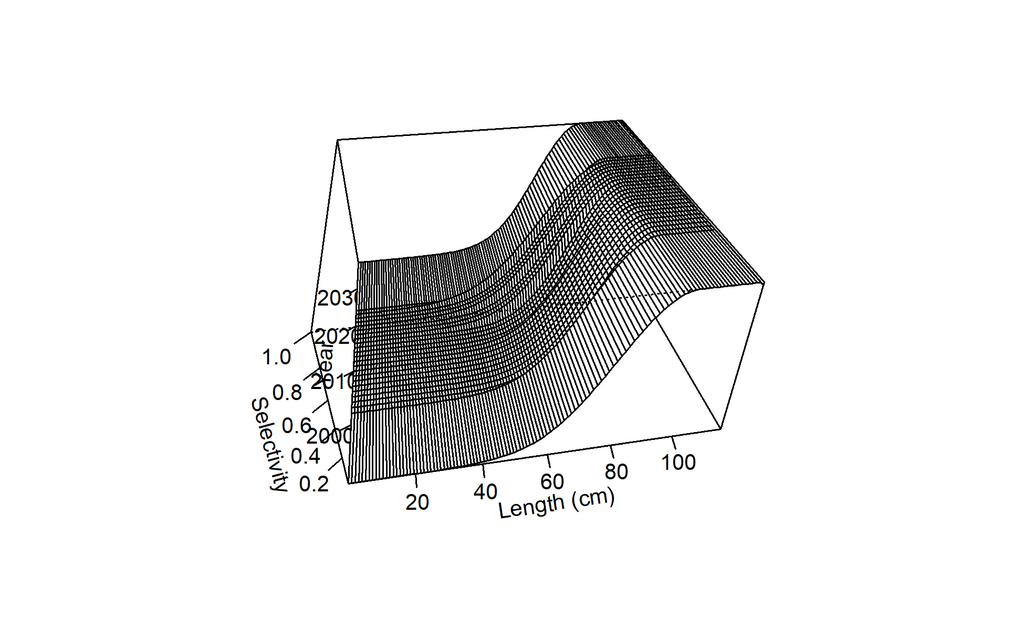

Figure 5. Time-varying fishery selectivity in M23.0b.